# Time-Aware Explainable ML — Phát hiện sớm sinh viên nguy cơ (OULAD)

Báo cáo tiến độ · Phase 2 — Benchmarking mô hình · DSP391m — Nhóm 1

Đức (Modeling Lead) — GVHD: Nguyễn Thị Hoàng Yến

02/07/2026 · Đại học FPT

# Phase 2 — Benchmarking · *Đức*

## Lựa chọn mô hình — vì sao 5 thuật toán này?

| Model | Họ thuật toán | Lý do chọn |
| --- | --- | --- |
| Logistic Regression | Tuyến tính | Baseline chuẩn, hệ số đọc được trực tiếp |
| Random Forest | Bagging cây | Bền với nhiễu/ngoại lai, ít phải tinh chỉnh |
| XGBoost | Boosting cây | SOTA dữ liệu bảng, hỗ trợ SHAP TreeExplainer |
| LightGBM | Boosting cây | Nhanh trên dữ liệu lớn, đối chứng cùng họ XGB |
| ANN (MLP) | Mạng nơ-ron | Đại diện phi tuyến khác họ cây, đối chứng đa dạng |

- Phủ **3 họ mô hình** khác nhau (tuyến tính · cây · nơ-ron) → kết luận không lệ thuộc một họ.
- Cả 5 đều được các nghiên cứu nền trên OULAD sử dụng → **so sánh được với văn liệu**.

## Kiến trúc & cấu hình huấn luyện

| Model | Cấu hình chính (còn lại giữ mặc định) |
| --- | --- |
| Logistic Regression | `max_iter=1000` |
| Random Forest | mặc định · `n_jobs=-1` |
| XGBoost | `tree_method=hist` · `eval_metric=logloss` |
| LightGBM | mặc định · `verbose=-1` |
| ANN (MLP) | 2 lớp ẩn **(64, 32)** · `max_iter=500` · early-stopping |

- **Cùng seed 42** cho mọi model → công bằng & tái lập.
- Giai đoạn này *chưa* tinh chỉnh siêu tham số — so tuyển ở cấu hình gốc trước, tinh chỉnh sau khi chọn.

## Quy trình huấn luyện (Training Procedure)

1. Nạp **split cố định** của mốc 100% (đã chốt ở Task 3 — 0 SV trùng train/test, 19/19 kiểm thử rò rỉ ĐẠT).
2. Tiền xử lý **fit trên train** → transform test (median, winsorize, encoder, scaler đều học từ train).
3. `model.fit(train)` → dự đoán trên **test giữ riêng**.
4. Chấm **7 chỉ số**; xếp hạng theo **Recall** lớp at-risk.
- Đây là kết quả **baseline (no-resample)** — Phase 4 sẽ so sánh trước–sau với 4 kỹ thuật cân bằng lớp.
- Chỉ số chính: **Recall & PR-AUC** lớp at-risk — bỏ sót SV nguy cơ đắt hơn nhiều một cảnh báo nhầm; accuracy dễ gây ảo tưởng.

## Kết quả so tuyển @ mốc 100%

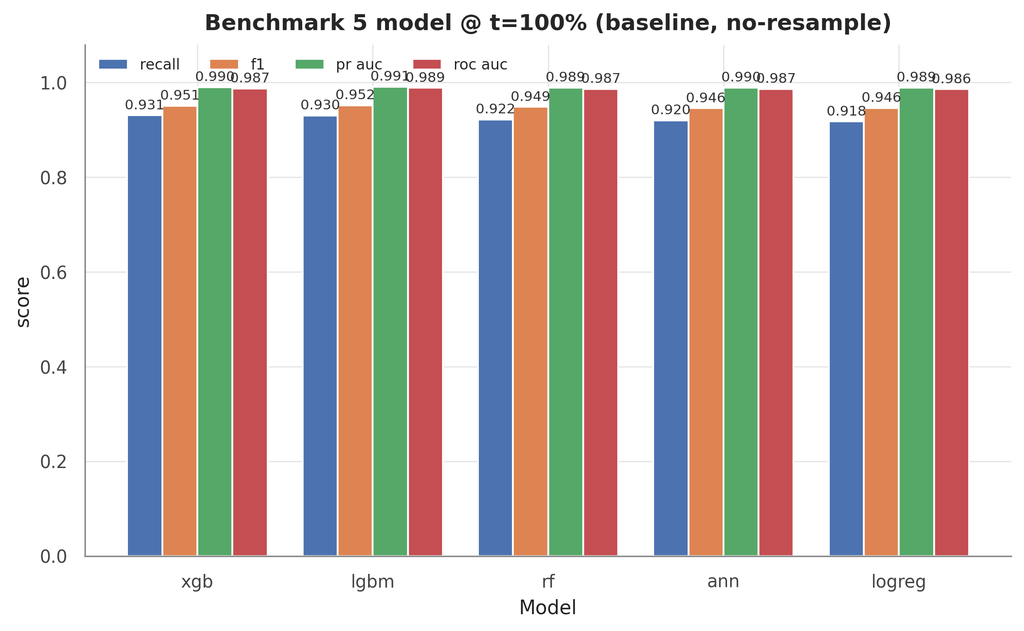

## Bảng hiệu năng đầy đủ — 7 chỉ số (đọc từ CSV)

**0.931**XGBoost · recall **0.990**PR-AUC **0.951**F1 **0.038**Brier (càng thấp càng tốt)

| Model | Recall | F1 | PR-AUC | ROC-AUC | Precision | Bal.Acc | Brier ↓ |
| --- | --- | --- | --- | --- | --- | --- | --- |
| XGBoost | 0.931 | 0.951 | 0.990 | 0.987 | 0.972 | 0.951 | 0.038 |
| LightGBM | 0.930 | 0.952 | 0.991 | 0.989 | 0.974 | 0.952 | 0.037 |
| Random Forest | 0.922 | 0.949 | 0.989 | 0.987 | 0.977 | 0.949 | 0.041 |
| ANN (MLP) | 0.920 | 0.946 | 0.990 | 0.987 | 0.973 | 0.946 | 0.041 |
| Logistic Reg. | 0.918 | 0.946 | 0.989 | 0.986 | 0.976 | 0.947 | 0.041 |

- Đánh giá trên **tập test giữ riêng**, sắp theo recall lớp at-risk; Brier đo chất lượng xác suất.
- Khoảng cách giữa các model **nhỏ** → cần kiểm chứng độ tin cậy trước khi kết luận.

## Độ tin cậy: CV 5-fold × 5 seed trên train

| Model | Recall (μ ± σ) | F1 (μ ± σ) | PR-AUC (μ ± σ) |
| --- | --- | --- | --- |
| XGBoost | 0.9309 ± 0.0047 | 0.9507 ± 0.0032 | 0.9901 ± 0.0008 |
| LightGBM | 0.9295 ± 0.0060 | 0.9516 ± 0.0036 | 0.9907 ± 0.0008 |
| ANN (MLP) | 0.9245 ± 0.0081 | 0.9463 ± 0.0038 | 0.9891 ± 0.0009 |
| Random Forest | 0.9202 ± 0.0051 | 0.9489 ± 0.0030 | 0.9889 ± 0.0009 |
| Logistic Reg. | 0.9180 ± 0.0054 | 0.9452 ± 0.0033 | 0.9887 ± 0.0010 |

## Xếp hạng có ý nghĩa thống kê không?

| Chỉ số | Model tốt nhất (mean rank) | Friedman χ² | p-value |
| --- | --- | --- | --- |
| recall | XGBoost | 73.8 | 3.5e-15 |
| f1 | LightGBM | 83.8 | 2.7e-17 |
| pr_auc | LightGBM | 82.6 | 4.9e-17 |
| roc_auc | LightGBM | 77.7 | 5.4e-16 |

# Kế hoạch & Kết luận

## Các việc sắp tới để hoàn thiện bài làm

| Phase — Công việc | Người | Sản phẩm / RQ |
| --- | --- | --- |
| Phase 4 — no-resample/class-weight/SMOTE/ADASYN | Đức | Biểu đồ so sánh · RQ3 |
| Phase 3 — chạy thực nghiệm 6 mốc thời gian | Khoa | Đường cong hiệu năng · RQ1 |
| Phase 5 — SHAP/LIME + độ ổn định giải thích | Bình | Giải thích mô hình · RQ2 |
| Phase 6a — Streamlit dashboard | An | App dự đoán + đóng gói |
| Phase 6b — Introduction / Literature Review | Sơn | Mở đầu + tổng quan + tài liệu |

*Theo luồng quy trình: Đức → Khoa → Bình → An (dashboard) / Sơn (lit review); báo cáo cuối do Khoa tổng hợp.*

## Kết luận

- **Đã xong & tái lập:** so tuyển 5 model ứng viên (Phase 2), trên nền dữ liệu đã chốt ở Task 3.
- **XGBoost** dẫn đầu recall (**0.931**) ngay ở baseline; các model bám sát.
- **Kế tiếp:** P4 mất cân bằng → P3 time-aware RQ1 → P5 XAI RQ2 → P6 dashboard & báo cáo.
- Nền tảng tái lập từ `src/` + `tools/`; **19/19** kiểm thử rò rỉ ĐẠT.

### Cảm ơn đã lắng nghe!